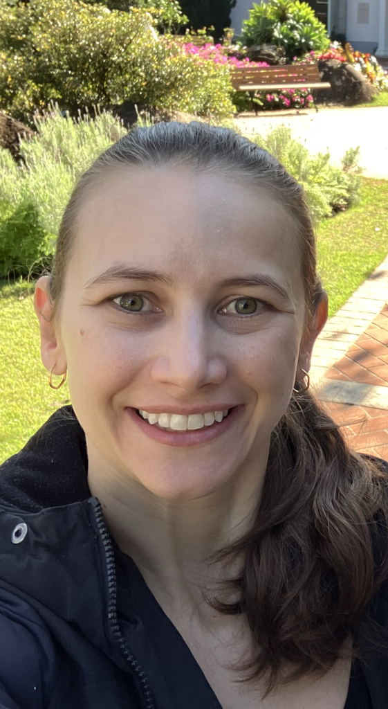

# About

[Twitter](https://x.com/flaviaerius) [LinkedIn](https://www.linkedin.com/in/fl%C3%A1via-eichemberger-rius-b5119770/) [Github](https://github.com/flaviaerius) email

Hi!

I’m Flávia!

I am a data scientist with a background on biomedical sciences. I have switched from wet lab to dry lab during my PhD, in which I studied cancer epigenomics, using a lot of bioinformatics both in R and bash.

Now I work as a data scientist in Mendelics, the biggest genomics laboratory of Latin America. Mostly I work with research and analysis of DNA sequencing data.

I also mentor people in R programming, statistics and bioinformatics.

I have 123 5-star reviews in [codementor](https://www.codementor.io/@flaviaerius). I really love to have this contact with people all over the world, and help them with their struggle coding or understanding a concept, especially because I’ve been there before and I know how hard that is.

I love learning new things!

I wanted to learn everything about everything! But I know I can’t, so I focus on some few topics at a time, being now mostly data science and genomics-related, apart from other variable topic.

I believe *mens sana in corpore sano* is totally true, so I like doing some exercise, and I have ran a couple of half marathons before - not suited for any ball-involving sport though.

Welcome! I hope you enjoy and that you can take something useful or entertaining from here :)

Feel free to send me an email or connect on LinkedIn with the links below.